# Test a Perceptual Phenomenon

The following statistical analysis is done on the Stroop effect. In the Stroop task, participants are presented with a list of words, with each word displayed in a color of ink. The participant’s task is to say out loud the color of the ink in which the word is printed. The task has two conditions: a congruent words condition, and an incongruent words condition. In the congruent words condition, the words being displayed are color words whose names match the colors in which they are printed. In the incongruent words condition, the words displayed are color words whose names do not match the colors in which they are printed. In each case, we measure the time it takes to name the ink colors in equally-sized lists. Each participant will go through and record a time from each condition.

### The Data Set which contains results from a number of participants in the task

```python
import pandas
df = pandas.read_csv('stroopdata.csv')
df
```

|  | Congruent | Incongruent |
| --- | --- | --- |
| 0 | 12.079 | 19.278 |
| 1 | 16.791 | 18.741 |
| 2 | 9.564 | 21.214 |
| 3 | 8.630 | 15.687 |
| 4 | 14.669 | 22.803 |
| 5 | 12.238 | 20.878 |
| 6 | 14.692 | 24.572 |
| 7 | 8.987 | 17.394 |
| 8 | 9.401 | 20.762 |
| 9 | 14.480 | 26.282 |
| 10 | 22.328 | 24.524 |
| 11 | 15.298 | 18.644 |
| 12 | 15.073 | 17.510 |
| 13 | 16.929 | 20.330 |
| 14 | 18.200 | 35.255 |
| 15 | 12.130 | 22.158 |
| 16 | 18.495 | 25.139 |
| 17 | 10.639 | 20.429 |
| 18 | 11.344 | 17.425 |
| 19 | 12.369 | 34.288 |
| 20 | 12.944 | 23.894 |
| 21 | 14.233 | 17.960 |
| 22 | 19.710 | 22.058 |
| 23 | 16.004 | 21.157 |

### 1. What is our independent variable? What is our dependent variable?

The independent variable is whether the condition i.e. if the word is a congruent word or an incongruent word. The dependent variable is the time it takes to name the ink colors.

### 2. What is an appropriate set of hypotheses for this task? What kind of statistical test do you expect to perform? Justify your choices.

#### Ho - Null Hypothesis

There is no significant difference in the record time from each condition i.e. congruent words condition and incongruent words condition for all the participants.

#### Ha - Alternative Hypothesis

There is a significant difference in the record time from each condition i.e. congruent words condition and incongruent words condition for all the participants.

#### Statistical Test

Statistical test used will be dependent sample two tailed t-test. It will be a dependent sample t-test because samples could be paired. It will be a two tailed t-test because one cannot say about the direction since the participants could read the word conditions faster or slower.

### 3. Report some descriptive statistics regarding this dataset. Include at least one measure of central tendency and at least one measure of variability.

#### Congruent Data

```python
print('Measure of Central Tendancy are:')
print('Mean   : ' + str("%.3f" % df['Congruent'].mean()))
print('Median : ' + str("%.3f" % df['Congruent'].median()))
print('\nMeasure of Variability are:')
print('Range               : ' + str(df['Congruent'].max() - df['Congruent'].min()))
print('Variance            : ' + str("%.3f" % df['Congruent'].var()))
print('Standard Deviation  : ' + str("%.3f" % df['Congruent'].std()))
```

```
Measure of Central Tendancy are:
Mean   : 14.051
Median : 14.357

Measure of Variability are:
Range               : 13.698
Variance            : 12.669
Standard Deviation  : 3.559
```

#### Incongruent Data

```python
print('Measure of Central Tendancy are:')
print('Mean   : ' + str("%.3f" % df['Incongruent'].mean()))
print('Median : ' + str("%.3f" % df['Incongruent'].median()))
print('\nMeasure of Variability are:')
print('Range               : ' + str(df['Incongruent'].max() - df['Incongruent'].min()))
print('Variance            : ' + str("%.3f" % df['Incongruent'].var()))
print('Standard Deviation  : ' + str("%.3f" % df['Incongruent'].std()))
```

```
Measure of Central Tendancy are:
Mean   : 22.016
Median : 21.017

Measure of Variability are:
Range               : 19.568
Variance            : 23.012
Standard Deviation  : 4.797
```

### 4. Provide one or two visualizations that show the distribution of the sample data. Write one or two sentences noting what you observe about the plot or plots.

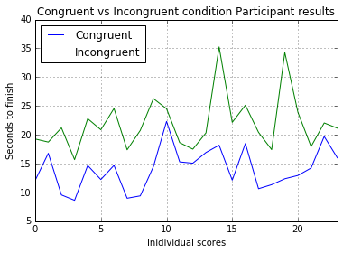

```python
%matplotlib inline
ax = df.plot(kind='line', grid=True);
ax.set_title('Congruent vs Incongruent condition Participant results');
ax.set_xlabel('Inidividual scores');
ax.set_ylabel('Seconds to finish');
```

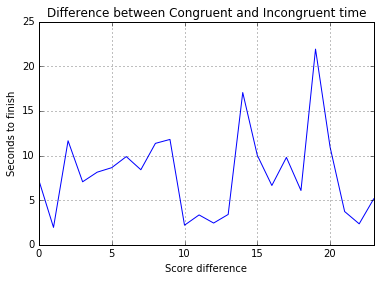

```python
df['Difference'] = df['Incongruent'] - df['Congruent']
ax = df['Difference'].plot(kind='line', grid=True);
ax.set_title('Difference between Congruent and Incongruent time');
ax.set_xlabel('Score difference');
ax.set_ylabel('Seconds to finish');
```

### 5. Now, perform the statistical test and report your results. What is your confidence level and your critical statistic value? Do you reject the null hypothesis or fail to reject it? Come to a conclusion in terms of the experiment task. Did the results match up with your expectations?

- Confidence Level = 90%
- Degree of Freedom = 23
- T Critical value = +- 1.711

```python
import math
std = df['Difference'].std()
#Number of samples
n = len(df)
# Standard Mean Error
sem = math.sqrt((std ** 2)/n)
# Point Estimate
pe = df['Difference'].mean()
# T Statistics
t = pe/sem
print("Value of T Statistics is " + str("%.3f" % t))
```

```
Value of T Statistics is 8.021
```

Since the value of t statistics is greater than value of t critical we reject the null hypothesis. This means that incongruence between colors and words impact our perceptions.